# Praca domowa 4

Krzysztof Rutkowski

Część 1

Tworzymy dwie obserwacje z 3 grupami: a, b oraz c. W pierwszym scenariuszu dodam 0.7 gdy pierwsza obserwacja przyjmie wartosc a. Powinnismy wiec zaobserwowac efekty dla pierwszej obserwacji.

```r
rep_size <- 2000
obs_size <- 500
pvals <- replicate(rep_size, {
  y <- rnorm(obs_size)
  obs1 <- sample(c("a","b", "c"), size=obs_size, replace=TRUE, prob=c(1/3,1/3,1/3))
  obs2 <- sample(c("a","b", "c"), size=obs_size, replace=TRUE, prob=c(1/3,1/3,1/3))
  eff <- which(obs1=="a")
  y[eff] <- y[eff] + 0.7

  anova(lm(y~obs1*obs2))[[5]][c(1,2,3)]

})
```

Hipoteza zerowa dla pierwszej obserwacji mówi, że średnie w grupach powinny być równe. Jako, że dodaliśmy czynnik 0.7 do jednej z grup powinniśmy się spodziewać odrzucenia hipotezy, a więc w znacznej większości przypadków p-wartość powinna być mniejsza niż 0.05.

```r
sum(pvals[1,] < 0.05) / rep_size
```

```
## [1] 1
```

I tak w istocie jest.

Hipoteza zerowa dla drugiej obserwacji mówi, że średnie w grupach powinny być równe. Tutaj nie dodawaliśmy czynnika, spodziewamy się więc równych średnich, a więc w znacznej większości przypadków p-wartość powinna być większa niż 0.05.

```r
sum(pvals[2,] < 0.05) / rep_size
```

```
## [1] 0.055
```

I tutaj również symulacje potwierdzają teorię.

Hipoteza zerowa dla interakcji mówi, że w modelu nie powinno być interakcji. Obserwacje były generowane niezależnie interakcji być nie powinno, toteż w znacznej większości przypadków p-wartość powinna być większa niż 0.05.

```r
sum(pvals[3,] < 0.05, na.rm = TRUE) / rep_size
```

```
## [1] 0.055
```

I tu również mamy zgodność.

Część 2

Teraz dodamy do naszego modelu zależności między obserwacjami. Powinny więc wystąpić efekty interakcji. Dodamy czynnik 0.7 jeśli obie obserwacje będą miały wartość “a”.

```r
rep_size <- 2000
obs_size <- 500
pvals <- replicate(rep_size, {
  y <- rnorm(obs_size)
  obs1 <- sample(c("a","b", "c"), size=obs_size, replace=TRUE, prob=c(1/3,1/3,1/3))
  obs2 <- sample(c("a","b", "c"), size=obs_size, replace=TRUE, prob=c(1/3,1/3,1/3))
  eff <- which(obs1=="a" & obs2=="a")
  y[eff] <- y[eff] + 0.7

  anova(lm(y~obs1*obs2))[[5]][c(1,2,3)]

})
```

Hipoteza zerowa dla pierwszej obserwacji mówi, że średnie w grupach powinny być równe. Tutaj nie dodawaliśmy czynnika dla tych obserwacji, ale wprowadzone efekty interakcji mogły zaburzyć średnie między grupami.

```r
sum(pvals[1,] < 0.05) / rep_size
```

```
## [1] 0.5765
```

Hipoteza zerowa dla drugiej obserwacji mówi, że średnie w grupach powinny być równe. Tutaj nie dodawaliśmy czynnika dla tych obserwacji, ale wprowadzone efekty interakcji mogły zaburzyć średnie między grupami.

```r
sum(pvals[2,] < 0.05) / rep_size
```

```
## [1] 0.5895
```

```r
sum(pvals[3,] < 0.05, na.rm = TRUE) / rep_size
```

```
## [1] 0.8065
```

Spójrzmy jeszcze na histogram:

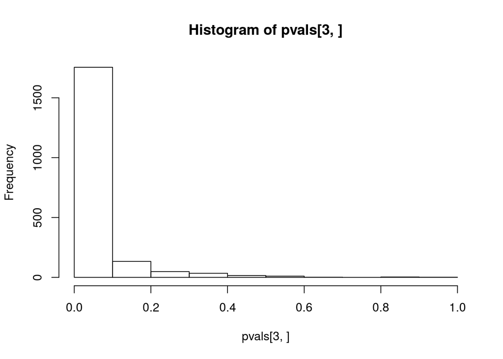

```r
hist(pvals[3,])
```

Widzimy, że faktycznie jest duże prawdopodobieństwo, że model potwierdzi wystąpienie interakcji.

Część 3

Teraz dodamy do naszego modelu zależności między obserwacjami oraz zaburzenie dla jednej z obserwacji. Powinny więc wystąpić zarówno efekty związane z jedną obserwacją efekty interakcji. Dodamy czynnik 0.7 jeśli obie obserwacje będą miały wartość “a” oraz jeśli jedna z obserwacji będzie miała wartośc “b”.

```r
rep_size <- 2000
obs_size <- 500
pvals <- replicate(rep_size, {
  y <- rnorm(obs_size)
  obs1 <- sample(c("a","b", "c"), size=obs_size, replace=TRUE, prob=c(1/3,1/3,1/3))
  obs2 <- sample(c("a","b", "c"), size=obs_size, replace=TRUE, prob=c(1/3,1/3,1/3))
  eff_int <- which(obs1=="a" & obs2=="a")
  eff_obs <- which(obs1=="b")
  y[eff_int] <- y[eff_int] + 0.7
  y[eff_obs] <- y[eff_obs] + 0.7

  anova(lm(y~obs1*obs2))[[5]][c(1,2,3)]

})
```

Hipoteza zerowa dla pierwszej obserwacji mówi, że średnie w grupach powinny być równe. Dodaliśmy czynnik dla jednej z grup w pierwszej obserwacji, a więc powinniśmy zaobserwować efekty. Spodziewamy się, że w większości przypadków p-wartośc powinna być mniejsza od 0.05.

```r
sum(pvals[1,] < 0.05) / rep_size
```

```
## [1] 1
```

I tak w istocie jest.

Hipoteza zerowa dla drugiej obserwacji mówi, że średnie w grupach powinny być równe. Tutaj nie dodawaliśmy czynnika dla tych obserwacji, ale wprowadzone efekty interakcji mogły zaburzyć średnie między grupami.

```r
sum(pvals[2,] < 0.05) / rep_size
```

```
## [1] 0.574
```

```r
sum(pvals[3,] < 0.05, na.rm = TRUE) / rep_size
```

```
## [1] 0.8105
```

Spójrzmy jeszcze na histogram:

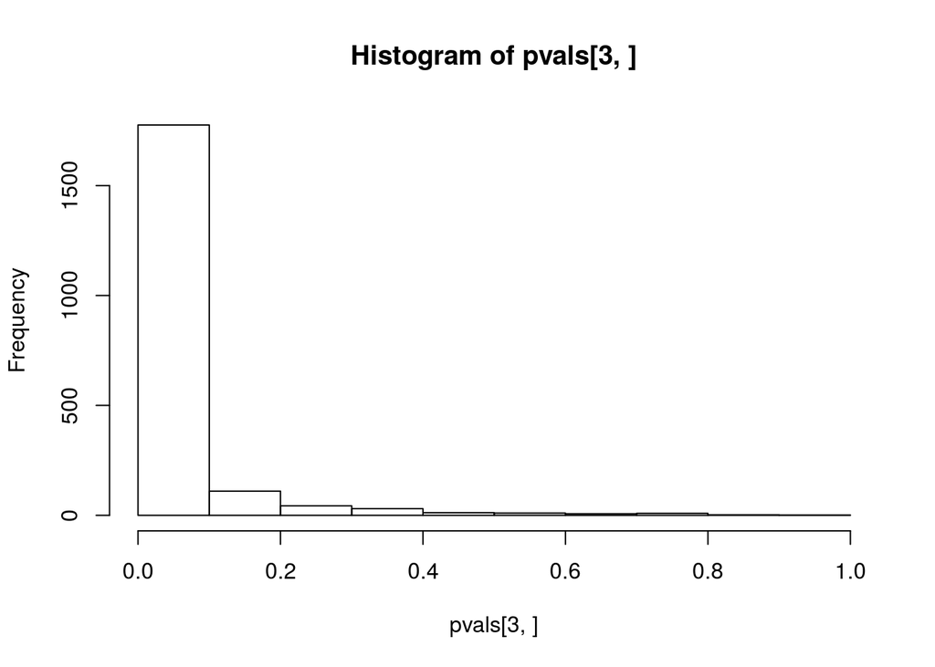

```r
hist(pvals[3,])
```

Widzimy, że jest bardzo duże prawdopodobieństwo, że model potwierdzi wystąpienie interakcji.